# Esboço do fluxo de trabalho de produção dos códigos

Luciana Fusinatto Vitor Borges-Júnior

Criado em 31 de março de 2023, atualizado em 19 de abril de 2023

# 1 **PARTE I – Cuidados antes de começar a rodar os códigos no R**

Pensar quais orientações são mais gerais e quais são importantes de acompanhar cada código.

## 1.1 **Rstudio/Pacotes/versões/sistemas operacionais**

Sobre os pacotes, seria bom ter uma listinha de ‘library’ no início de cada código? Talvez com uma breve explicação do que cada pacote faz, versão mínima… não sei.

**OBS**: essa tabela é uma referência para obtermos as versões dos pacotes ao final do desenvolvimento do script. Ela está automatizada, então quando terminarmos ele precisamos refaze-lo de forma que não gere mais mudança nas versões (tem que fazer a tabela na mão mesmo…).

```r
# gerar informações sobre os pacotes carregados
info <- sessionInfo()

# gerar tabela com os pacotes e versões
tribble(
  ~Pacotes,                         ~Versão,
  version$language,                 version$version.string,
  info$otherPkgs$dplyr$Package,     info$otherPkgs$dplyr$Version,
  #info$otherPkgs$Distance$Package,  info$otherPkgs$Distance$Version,
  info$otherPkgs$DT$Package,        info$otherPkgs$DT$Version,
  info$otherPkgs$flextable$Package, info$otherPkgs$flextable$Version,
  info$otherPkgs$ggplot2$Package,     info$otherPkgs$ggplot2$Version,
  info$otherPkgs$lubridate$Package,     info$otherPkgs$lubridate$Version,
  info$otherPkgs$plotly$Package,    info$otherPkgs$plotly$Version,
  info$otherPkgs$readr$Package,     info$otherPkgs$readr$Version,
  info$otherPkgs$readxl$Package,     info$otherPkgs$readxl$Version,
  info$otherPkgs$stringr$Package,     info$otherPkgs$stringr$Version,
  info$otherPkgs$tibble$Package,    info$otherPkgs$tibble$Version,
  info$otherPkgs$tidyr$Package,     info$otherPkgs$tidyr$Version
) |>
  qflextable() |>
  set_caption(
    "Tabela xx - configuração de pacotes necessários e respectivas versões mínimas que devem ser utilizadas para reproduzir os códigos"
  )
```

| Pacotes | Versão |
| --- | --- |
| R | R version 4.2.3 (2023-03-15) |
| dplyr | 1.1.1 |
| DT | 0.27 |
| flextable | 0.9.1 |
| ggplot2 | 3.4.2 |
| lubridate | 1.9.2 |
| plotly | 4.10.1 |
| readr | 2.1.4 |
| readxl | 1.4.2 |
| stringr | 1.5.0 |
| tibble | 3.2.1 |
| tidyr | 1.3.0 |

## 1.2 **Cuidados com a planilha .xlsx que será importada (para que mantenha o padrão da planilha de referência do ICMBio)**

O primeiro e mais importante cuidado é **manter a consistência dos nomes das colunas** em versões atualizadas da base de dados do Monitora. Além de carregar os dados, a função `carregar_dados_completos()` aplica uma série de transformações nas colunas. Seus nomes são alterados, e a essas são atribuídos tipos apropriados (data, caracter, fator, inteiro e numérico), linhas são eliminadas e novas colunas são gereadas. Para exemplificar, veja o código abaixo. Ele foi escrito para executar as primeiras transformações nos dados e constitui o corpo da função `carregar_dados_filtrados()`.

```r
# carregar a base de dados do Monitora
dados_brutos <- carregar_dados_brutos_xlsx()

# gerar o data.frame desejado reproduzindo as transformações realizadas pela função carregar_dados_completos()
dados_filtrados <- dados_brutos |>
  # selecionar as colunas necessárias para as analises, padronizando os nomes para o formato DISTANCE
  dplyr::select(
    uc_code = CDUC,
    uc_name = `Local - Nome da Unidade de Conservação`,
    ea_number = `Número da Estação Amostral`,
    ea_name = `Nome da EA`,
    season = `Estação do ano`,
    sampling_day = `data da amostragem`,
    day_effort = `Esforço de amostragem tamanho da trilha (m)`,
    sp = `Espécies validadas para análise do ICMBio`,
    distance = `distância (m)     do animal em relação a trilha`,
    group_size = `n° de animais`,
    observadores = `nome dos observadores`
  ) |>
  # atribuir os tipos corretos às colunas e criar novas colunas
    dplyr::mutate(
      uc_category = stringi::stri_extract_first_words(
      uc_name
    ),
    # abrevia o nome das UCs
    uc_name_abv = forcats::lvls_revalue(
      uc_name,
      new_levels = c(
        "ETM", "EM", "EN", "ESGT", "FJ", "PCV", "PA", "PSBoc", "PSBod", "PSC",
        "PSM", "PSC", "PSD", "PSP", "PSO", "PPN", "PCO", "PI", "PJaú", "PJur",
        "PMR", "PS", "PV", "PCA", "PMT", "RG", "RJ", "RTap", "RU", "RG",
        "RTrom", "RAT", "RBA", "RCI", "RCM", "RRC", "RROP", "RIA", "RRA", "RTA"
      )
    ),
      # atribuir o tipo data à coluna sampling_day
      year = lubridate::year(
        sampling_day
      ),
      # atribuir o tipo fator às colunas do tipo caracter
      across(
        where(
          is.character
        ),
        as.factor
      ),
      # substituir separadores de nome por ","
      novo = stringr::str_replace_all(
        observadores,
        " e ",
        ", "
      ),
      # substituir separadores de nome por ","
      novo = stringr::str_replace_all(
        novo,
        " E ",
        ", "
      ),
      # substituir separadores de nome por ","
      novo = stringr::str_replace_all(
        novo,
        "/",
        ", "
      ),
      # substituir separadores de nome por ","
      novo = stringr::str_replace_all(
        novo,
        ";",
        ", "
      ),
      # substituir separadores de nome por ","
      novo = stringr::str_replace_all(
        novo,
        " a ",
        ", "
      )
    ) |>
  # transformar os nomes dos observadores da coluna novo em colunas individuais
tidyr::separate_wider_delim(
  novo,
  ",",
  names = c(
    "obs1", "obs2", "obs3", "obs4", "obs5", "obs6"
  ),
  too_few = "align_start"
) |>
  # gerar uma nova coluna number_observers com o número total de observadores em um mesmo transecto
  dplyr::mutate(
    # se o valor da observação é diferente de NA, substituir por 1, se for NA, substituir por 0
    obs1 = ifelse(!is.na(obs1), 1, 0),
    obs2 = ifelse(!is.na(obs2), 1, 0),
    obs3 = ifelse(!is.na(obs3), 1, 0),
    obs4 = ifelse(!is.na(obs4), 1, 0),
    obs5 = ifelse(!is.na(obs5), 1, 0),
    obs6 = ifelse(!is.na(obs6), 1, 0),
    # gera nova coluna number_observers a partir da soma das colunas de observadores individuais
    number_observers = obs1 + obs2 + obs3 + obs4 + obs5 + obs6
  ) |>
  # agrupar os dados pelas colunas ea_name e sampling_day
  group_by(
    ea_name,
    sampling_day
  ) |>
  # aninhar as observações agrupadas uem listas
  nest() |>
  # completar com o valor correto as linhas vazias das da variável day_effort
  mutate(
    day_effort2 = purrr::map(
      data, \(.x) rep(
        .x$day_effort[
          !is.na(
            .x$day_effort
          )
        ][1]
      )
    )
  ) |>
  # desanihar os dados
  unnest(
    c(
      data,
      day_effort2
    )
  ) |>
  # desagrupar os dados
  ungroup() |>
  # selecionar as colunas desejadas e excluir as indesejadas
  select(
    tidyselect::starts_with(c("uc", "ea")),
    season,
    year,
    sampling_day,
    day_effort = day_effort2,
    sp:number_observers,
    -day_effort,
    -tidyselect::starts_with("obs")
  ) |>
  # filtrar os dados pela UC e espécie desejadas
    dplyr::filter(
      uc_name == "Resex Tapajós-Arapiuns",
      sp == "Dasyprocta croconota"
    ) |>
  relocate(
    uc_category,
    .before = uc_name
  ) |>
  relocate(
    uc_name_abv,
    .after = uc_name
  )

# gerar tabela dinâmica dos dados filtrados
dados_filtrados |>
  slice(
    1:1000
  ) |>
  datatable(
    filter = list(
      position = "top"
    )
  )
```

O trecho do código que vai da linha 103 a 115 serve selecionar apenas as colunas de interesse presente nos dados originais. Note que os nomes das planilhas originais constam nesse trecho. Caso o nome de qualque uma dessas colunas seja alterado a função deixará de funcionar.

Dentre todas as funções de carregamento de dados, apenas `carregar_dados_brutos_xlsx()` carrega a base de dados originais do Monitora, diretamente do diretório `data-raw/monitora_masto_aves_2023_04_04.xlsx`. Ao mesmo tempo que carrega e transforma os dados, essa função gera uma versão em um formato mais leve, `.rds`, no diretório `data-raw` (`data-raw/monitora_masto_aves_2023_04_04.rds`). A função seguinte no fluxo de trabalho carrega a base a partir dessa versão mais leve. Logo, sempre que houver atualizações no arquivo original de dados brutos é necessário iniciar a rotina de carregamento de dados necessariamente com a função `carregar_dados_brutos_xlsx()`.

Outros cuidados…

Imaginando que a planilha de dados do monitora é algo dinâmico, que o nome das colunas pode ser editado…

## 1.3 **Como abrir os arquivos: como salvar e descompactar a pasta. Abrir projeto**

Um passo a passo de como salvar arquivo com os códigos e abrir.. Por exemplo, da forma como está é interessante descompactar a pasta e acessar os arquivos abrindo o projeto. Acho que isso pode mudar, dependendo de como viermos a entregar o produto final. Então podemos pensar nessa explicação no final.

## 1.4 **Cuidados com diretório**

Se a gente ainda precisar ter algum tipo de preocupação quanto a isso. Acho que não. Explicar a estrtura de diretórios do projeto.

## 1.5 **Como rodar cada tipo de arquivo (markdown, shiny)**

Não é trivial para quem não está acostumado… usar runApp, knit… até mesmo o shift+enter para rodar as linhas de comando uma a uma

# 2 **PARTE II – Carregando os dados para o R**

## 2.1 **Dados brutos**

```r
# carregar dados brutos
dados_brutos <- carregar_dados_brutos_xlsx()
dados_brutos
```

| CDUC | Local - Nome da Unidade de Conservação | Número da Estação Amostral | Nome da EA | Esforço de amostragem tamanho da trilha (m) | data da amostragem | Ano | Estação do ano | horário de início (h:mm) | horário de término (h:mm) | Tempo de censo | velocidade (km/h) | condição climática: ensolarado, nublado e chuvoso | nome dos observadores | Número do animal no guia | Classe | Ordem | Família | Gênero | Espécies | Clasificação taxonômica (espécie, gênero, família ou ordem) | Espécies validadas para análise do ICMBio | Clasificação taxonômica validada | horário do avistamento | n° de animais | contagem total ou parcial? | distância (m) do animal em relação a trilha | marcação no transecto | teve problema durante a amostragem? | Observações |
| --- | --- | --- | --- | --- | --- | --- | --- | --- | --- | --- | --- | --- | --- | --- | --- | --- | --- | --- | --- | --- | --- | --- | --- | --- | --- | --- | --- | --- | --- |
| 47 | Esec da Terra do Meio | 1 | Trilha da Fazenda | 4650 | 2014-10-22 | 2014 | Seca | 1899-12-31 06:30:00 | 1899-12-31 11:10:00 | 1899-12-31 04:40:00 | 0.9964286 | nublado | Carlos e Milton | 56 | Aves | Galliformes | Odontophoridae | Odontophorus | Odontophorus gujanensis | E | Odontophorus gujanensis | E | 1899-12-31 06:34:00 | 2 | total | 0.00 | 100 | Não | Trilha com 4650 m |
| 47 | Esec da Terra do Meio | 1 | Trilha da Fazenda | NA | 2014-10-22 | 2014 | Seca | 1899-12-31 06:30:00 | 1899-12-31 11:10:00 |  | NA | nublado | Carlos e Milton | 277 | Mammalia | Primates | Pitheciidae | Callicebus | Callicebus sp. | G | Callicebus vieirai | E | 1899-12-31 06:48:00 | 2 | total | 13.36 | 400 | Não | NA |
| 47 | Esec da Terra do Meio | 1 | Trilha da Fazenda | NA | 2014-10-22 | 2014 | Seca | 1899-12-31 06:30:00 | 1899-12-31 11:10:00 |  | NA | nublado | Carlos e Milton | 56 | Aves | Galliformes | Odontophoridae | Odontophorus | Odontophorus gujanensis | E | Odontophorus gujanensis | E | 1899-12-31 07:05:00 | 1 | total | 3.75 | 450 | Não | NA |
| 47 | Esec da Terra do Meio | 1 | Trilha da Fazenda | NA | 2014-10-22 | 2014 | Seca | 1899-12-31 06:30:00 | 1899-12-31 11:10:00 |  | NA | nublado | Carlos e Milton | 277 | Mammalia | Primates | Pitheciidae | Callicebus | Callicebus sp. | G | Callicebus vieirai | E | 1899-12-31 07:25:00 | 4 | total | 13.52 | 800 | Não | NA |
| 47 | Esec da Terra do Meio | 1 | Trilha da Fazenda | NA | 2014-10-22 | 2014 | Seca | 1899-12-31 06:30:00 | 1899-12-31 11:10:00 |  | NA | nublado | Carlos e Milton | 139 | Mammalia | Rodentia | Dasyproctidae | Dasyprocta | Dasyprocta sp. | G | Dasyprocta croconota | E | 1899-12-31 08:17:00 | 1 | total | 7.75 | 1900 | Não | NA |
| 47 | Esec da Terra do Meio | 1 | Trilha da Fazenda | NA | 2014-10-22 | 2014 | Seca | 1899-12-31 06:30:00 | 1899-12-31 11:10:00 |  | NA | nublado | Carlos e Milton | 139 | Mammalia | Rodentia | Dasyproctidae | Dasyprocta | Dasyprocta sp. | G | Dasyprocta croconota | E | 1899-12-31 09:36:00 | 1 | total | 1.70 | 3000 | Não | NA |
| 47 | Esec da Terra do Meio | 1 | Trilha da Fazenda | NA | 2014-10-22 | 2014 | Seca | 1899-12-31 06:30:00 | 1899-12-31 11:10:00 |  | NA | nublado | Carlos e Milton | 156 | Mammalia | Rodentia | Sciuridae | Guerlinguetus | Guerlinguetus aestuans | E | Guerlinguetus aestuans | E | 1899-12-31 09:43:00 | 1 | total | 8.78 | 3100 | Não | Guerlinguetus cf. brasiliensis |
| 47 | Esec da Terra do Meio | 1 | Trilha da Fazenda | NA | 2014-10-22 | 2014 | Seca | 1899-12-31 06:30:00 | 1899-12-31 11:10:00 |  | NA | nublado | Carlos e Milton | 3 | Aves | Galliformes | Cracidae | Crax | Crax fasciolata | E | Crax fasciolata | E | 1899-12-31 09:50:00 | 2 | total | 0.00 | 3150 | Não | NA |
| 47 | Esec da Terra do Meio | 1 | Trilha da Fazenda | NA | 2014-10-22 | 2014 | Seca | 1899-12-31 06:30:00 | 1899-12-31 11:10:00 |  | NA | nublado | Carlos e Milton | 17 | Aves | Galliformes | Cracidae | Penelope | Penelope pileata | E | Penelope sp. | G | 1899-12-31 10:13:00 | 1 | total | 2.50 | 3850 | Não | NA |
| 47 | Esec da Terra do Meio | 1 | Trilha da Fazenda | NA | 2014-10-22 | 2014 | Seca | 1899-12-31 06:30:00 | 1899-12-31 11:10:00 |  | NA | nublado | Carlos e Milton | 17 | Aves | Galliformes | Cracidae | Penelope | Penelope pileata | E | Penelope sp. | G | 1899-12-31 10:36:00 | 1 | total | 7.82 | 4150 | Não | NA |

[output cut: 990 more lines]

## 2.2 **Dados completos**

- todas espécies/UCs – carrega_dados_1.Rmd Descrever o que os dados trazem e porque foram formatados dessa forma.

```r
# carregar dados para o R
dados_completos <- carregar_dados_completos()
dados_completos
```

| uc_code | uc_category | uc_name | uc_name_abv | ea_name | ea_number | season | year | sampling_day | day_effort | sp_name | sp_name_abv | validation | distance | group_size | number_observers | cense_time |
| --- | --- | --- | --- | --- | --- | --- | --- | --- | --- | --- | --- | --- | --- | --- | --- | --- |
| 47 | Esec | Esec da Terra do Meio | ETM | Trilha da Fazenda | 1 | Seca | 2014 | 2014-10-22 | 4650 | Odontophorus gujanensis | Odon. guja. | Espécie | 0.00 | 2 | 2 | 280 mins |
| 47 | Esec | Esec da Terra do Meio | ETM | Trilha da Fazenda | 1 | Seca | 2014 | 2014-10-22 | 4650 | Callicebus vieirai | Call. viei. | Espécie | 13.36 | 2 | 2 | 280 mins |
| 47 | Esec | Esec da Terra do Meio | ETM | Trilha da Fazenda | 1 | Seca | 2014 | 2014-10-22 | 4650 | Odontophorus gujanensis | Odon. guja. | Espécie | 3.75 | 1 | 2 | 280 mins |
| 47 | Esec | Esec da Terra do Meio | ETM | Trilha da Fazenda | 1 | Seca | 2014 | 2014-10-22 | 4650 | Callicebus vieirai | Call. viei. | Espécie | 13.52 | 4 | 2 | 280 mins |
| 47 | Esec | Esec da Terra do Meio | ETM | Trilha da Fazenda | 1 | Seca | 2014 | 2014-10-22 | 4650 | Dasyprocta croconota | Dasy. croc. | Espécie | 7.75 | 1 | 2 | 280 mins |
| 47 | Esec | Esec da Terra do Meio | ETM | Trilha da Fazenda | 1 | Seca | 2014 | 2014-10-22 | 4650 | Dasyprocta croconota | Dasy. croc. | Espécie | 1.70 | 1 | 2 | 280 mins |
| 47 | Esec | Esec da Terra do Meio | ETM | Trilha da Fazenda | 1 | Seca | 2014 | 2014-10-22 | 4650 | Guerlinguetus aestuans | Guer. aest. | Espécie | 8.78 | 1 | 2 | 280 mins |
| 47 | Esec | Esec da Terra do Meio | ETM | Trilha da Fazenda | 1 | Seca | 2014 | 2014-10-22 | 4650 | Crax fasciolata | Crax. fasc. | Espécie | 0.00 | 2 | 2 | 280 mins |
| 47 | Esec | Esec da Terra do Meio | ETM | Trilha da Fazenda | 1 | Seca | 2014 | 2014-10-22 | 4650 | Penelope sp. | Pene. sp.. | Gênero | 2.50 | 1 | 2 | 280 mins |
| 47 | Esec | Esec da Terra do Meio | ETM | Trilha da Fazenda | 1 | Seca | 2014 | 2014-10-22 | 4650 | Penelope sp. | Pene. sp.. | Gênero | 7.82 | 1 | 2 | 280 mins |

[output cut: 990 more lines]

## 2.3 **Dados filtrados**

- por espécie/UC – carrega_dados_2.Rmd até o momento usado com o exemplo da cutia na Resex Tapajós-Arapiuns Descrever o que os dados trazem e porque foram formatados dessa forma.

```r
# carregar dados para o R
dados_filtrados <- carregar_dados_filtrados()
dados_filtrados
```

| uc_code | uc_category | uc_name | uc_name_abv | ea_name | ea_number | season | year | sampling_day | day_effort | sp_name | sp_name_abv | validation | distance | group_size | number_observers | cense_time |
| --- | --- | --- | --- | --- | --- | --- | --- | --- | --- | --- | --- | --- | --- | --- | --- | --- |
| 259 | Resex | Resex Tapajós-Arapiuns | RTA | Boim | 1 | Chuvosa | 2015 | 2015-02-06 | 5000 | Dasyprocta croconota | Dasy. croc. | Espécie | 10.00 | 1 | 2 | 525 mins |
| 259 | Resex | Resex Tapajós-Arapiuns | RTA | Boim | 1 | Seca | 2015 | 2015-06-28 | 5000 | Dasyprocta croconota | Dasy. croc. | Espécie | 20.00 | 1 | 2 | 600 mins |
| 259 | Resex | Resex Tapajós-Arapiuns | RTA | Boim | 1 | Seca | 2015 | 2015-06-29 | 5000 | Dasyprocta croconota | Dasy. croc. | Espécie | 28.00 | 1 | 2 | 600 mins |
| 259 | Resex | Resex Tapajós-Arapiuns | RTA | Boim | 1 | Seca | 2015 | 2015-06-30 | 5000 | Dasyprocta croconota | Dasy. croc. | Espécie | 30.00 | 1 | 2 | 645 mins |
| 259 | Resex | Resex Tapajós-Arapiuns | RTA | Boim | 1 | Seca | 2015 | 2015-10-22 | 5000 | Dasyprocta croconota | Dasy. croc. | Espécie | 4.00 | 1 | 2 | 215 mins |
| 259 | Resex | Resex Tapajós-Arapiuns | RTA | Boim | 1 | Seca | 2015 | 2015-10-22 | 5000 | Dasyprocta croconota | Dasy. croc. | Espécie | 10.00 | 1 | 2 | 215 mins |
| 259 | Resex | Resex Tapajós-Arapiuns | RTA | Boim | 1 | Seca | 2015 | 2015-10-22 | 5000 | Dasyprocta croconota | Dasy. croc. | Espécie | 20.00 | 1 | 2 | 215 mins |
| 259 | Resex | Resex Tapajós-Arapiuns | RTA | Boim | 1 | Seca | 2015 | 2015-10-22 | 5000 | Dasyprocta croconota | Dasy. croc. | Espécie | 6.00 | 1 | 2 | 215 mins |
| 259 | Resex | Resex Tapajós-Arapiuns | RTA | Boim | 1 | Seca | 2015 | 2015-10-23 | 5000 | Dasyprocta croconota | Dasy. croc. | Espécie | 10.00 | 2 | 2 | 78 mins |
| 259 | Resex | Resex Tapajós-Arapiuns | RTA | Boim | 1 | Seca | 2015 | 2015-10-23 | 5000 | Dasyprocta croconota | Dasy. croc. | Espécie | 6.00 | 1 | 2 | 78 mins |

[output cut: 990 more lines]

# 3 **Parte III – Transformando dados para Distance**

## 3.1 **Dados completos**

- todas espécies/UCs – transformar_para_distanceR.Rmd

```r
# transformar os dados para o formato do Distance
dados_distanceR_completo <- transformar_para_distanceR()
dados_distanceR_completo
```

| uc_code | uc_name | ea_number | Region.Label | year | season | Area | Sample.Label | Effort | sp_name | sp_name_abv | distance | size | number_observers |
| --- | --- | --- | --- | --- | --- | --- | --- | --- | --- | --- | --- | --- | --- |
| 47 | Esec da Terra do Meio | 1 | Trilha da Fazenda | 2014 | Seca | 0 | 2014-10-22 | 4650 | Odontophorus gujanensis | Odon. guja. | 0.00 | 2 | 2 |
| 47 | Esec da Terra do Meio | 1 | Trilha da Fazenda | 2014 | Seca | 0 | 2014-10-22 | 4650 | Callicebus vieirai | Call. viei. | 13.36 | 2 | 2 |
| 47 | Esec da Terra do Meio | 1 | Trilha da Fazenda | 2014 | Seca | 0 | 2014-10-22 | 4650 | Odontophorus gujanensis | Odon. guja. | 3.75 | 1 | 2 |
| 47 | Esec da Terra do Meio | 1 | Trilha da Fazenda | 2014 | Seca | 0 | 2014-10-22 | 4650 | Callicebus vieirai | Call. viei. | 13.52 | 4 | 2 |
| 47 | Esec da Terra do Meio | 1 | Trilha da Fazenda | 2014 | Seca | 0 | 2014-10-22 | 4650 | Dasyprocta croconota | Dasy. croc. | 7.75 | 1 | 2 |
| 47 | Esec da Terra do Meio | 1 | Trilha da Fazenda | 2014 | Seca | 0 | 2014-10-22 | 4650 | Dasyprocta croconota | Dasy. croc. | 1.70 | 1 | 2 |
| 47 | Esec da Terra do Meio | 1 | Trilha da Fazenda | 2014 | Seca | 0 | 2014-10-22 | 4650 | Guerlinguetus aestuans | Guer. aest. | 8.78 | 1 | 2 |
| 47 | Esec da Terra do Meio | 1 | Trilha da Fazenda | 2014 | Seca | 0 | 2014-10-22 | 4650 | Crax fasciolata | Crax. fasc. | 0.00 | 2 | 2 |
| 47 | Esec da Terra do Meio | 1 | Trilha da Fazenda | 2014 | Seca | 0 | 2014-10-22 | 4650 | Penelope sp. | Pene. sp.. | 2.50 | 1 | 2 |
| 47 | Esec da Terra do Meio | 1 | Trilha da Fazenda | 2014 | Seca | 0 | 2014-10-22 | 4650 | Penelope sp. | Pene. sp.. | 7.82 | 1 | 2 |

[output cut: 990 more lines]

Em princípio tudo certo até aqui.

```r
# transformar os dados para o formato do Distance
dados_distance_r_covariaveis <- transformar_para_distanceR_covariaveis()
dados_distance_r_covariaveis
```

| Region.Label | Area | Sample.Label | Effort | sp_name | sp_name_abv | distance | year | size | cense_time | object |
| --- | --- | --- | --- | --- | --- | --- | --- | --- | --- | --- |
| Trilha da Fazenda | 0 | 2014-10-22 | 4650 | Odontophorus gujanensis | Odon. guja. | 0.00 | 2014 | 2 | 280 mins | 1 |
| Trilha da Fazenda | 0 | 2014-10-22 | 4650 | Callicebus vieirai | Call. viei. | 13.36 | 2014 | 2 | 280 mins | 2 |
| Trilha da Fazenda | 0 | 2014-10-22 | 4650 | Odontophorus gujanensis | Odon. guja. | 3.75 | 2014 | 1 | 280 mins | 3 |
| Trilha da Fazenda | 0 | 2014-10-22 | 4650 | Callicebus vieirai | Call. viei. | 13.52 | 2014 | 4 | 280 mins | 4 |
| Trilha da Fazenda | 0 | 2014-10-22 | 4650 | Dasyprocta croconota | Dasy. croc. | 7.75 | 2014 | 1 | 280 mins | 5 |
| Trilha da Fazenda | 0 | 2014-10-22 | 4650 | Dasyprocta croconota | Dasy. croc. | 1.70 | 2014 | 1 | 280 mins | 6 |
| Trilha da Fazenda | 0 | 2014-10-22 | 4650 | Guerlinguetus aestuans | Guer. aest. | 8.78 | 2014 | 1 | 280 mins | 7 |
| Trilha da Fazenda | 0 | 2014-10-22 | 4650 | Crax fasciolata | Crax. fasc. | 0.00 | 2014 | 2 | 280 mins | 8 |
| Trilha da Fazenda | 0 | 2014-10-22 | 4650 | Penelope sp. | Pene. sp.. | 2.50 | 2014 | 1 | 280 mins | 9 |
| Trilha da Fazenda | 0 | 2014-10-22 | 4650 | Penelope sp. | Pene. sp.. | 7.82 | 2014 | 1 | 280 mins | 10 |

[output cut: 990 more lines]

# 4 **PARTE IV – Explorando e selecionando os dados para as análises**

## 4.1 **Selecionando os melhores modelos de estudo de acordo com os dados**

Critŕios:

- espécies com maior volume de dados total
- maior volume de dados por UC – exploração_01.nb.html (acho que o .Rmd para gerar esse html não está na pasta Monitora). Eu tinha gostado bastante desse documento, com as tabelas dinâmicas. Talvez dê para selecionar as perguntas que são válidas de deixar/ tirar/ incluir. WWF - Projeto Monitora
- espécies validadas
- …

### 4.1.1 **Exploração e seleção de dados**

#### 4.1.1.1 **Aspectos relacionados ao número total de observações**

Sistematizar os critérios utilizados para eliminar observações (linhas).

Pensar num esquema de árvore de decisão para se chegar ao subconjunto de dados que será analisados.

#### 4.1.1.2 **Quantas observações foram validadas para quais níveis taxonômicos?**

Essas operações são realizadas sobre a tabela de dados `dados_completos` pois os dados que foram transformados para o formato do distace no R não possuem a coluna `validation`, necessária para essas opereações. Mais a frente o procedimento de como obter os dados selecionados e transformatos para o formato das análises será demonstrado.

```r
# contar observações validadas ao nível de espécie
n_obs_validadas <- contar_n_obs_validadas()
n_obs_validadas
```

```
[1] 20790   318  6550    14   215
```

Foram selecionadas apenas as observações validadas ao nível de espécie, somando um total 20790 observações.

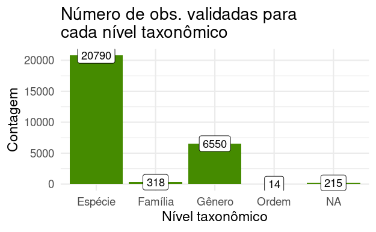

```r
# gerar gráfico com número observações validadas para cada nível taxonômico
plotar_n_obs_validadas_estatico()
```

Filnalmente chegamos ao subconjunto dos dados que será utilizado para selecionar quais espécies serão analisadas.

```r
# gerar tabela de dados selecionados
dados_selecionados <- carregar_dados_selecionados()
dados_selecionados
```

| uc_code | uc_category | uc_name | uc_name_abv | ea_name | ea_number | season | year | sampling_day | day_effort | sp_name | sp_name_abv | validation | distance | group_size | number_observers | cense_time |
| --- | --- | --- | --- | --- | --- | --- | --- | --- | --- | --- | --- | --- | --- | --- | --- | --- |
| 47 | Esec | Esec da Terra do Meio | ETM | Trilha da Fazenda | 1 | Seca | 2014 | 2014-10-22 | 4650 | Odontophorus gujanensis | Odon. guja. | Espécie | 0.00 | 2 | 2 | 280 mins |
| 47 | Esec | Esec da Terra do Meio | ETM | Trilha da Fazenda | 1 | Seca | 2014 | 2014-10-22 | 4650 | Callicebus vieirai | Call. viei. | Espécie | 13.36 | 2 | 2 | 280 mins |
| 47 | Esec | Esec da Terra do Meio | ETM | Trilha da Fazenda | 1 | Seca | 2014 | 2014-10-22 | 4650 | Odontophorus gujanensis | Odon. guja. | Espécie | 3.75 | 1 | 2 | 280 mins |
| 47 | Esec | Esec da Terra do Meio | ETM | Trilha da Fazenda | 1 | Seca | 2014 | 2014-10-22 | 4650 | Callicebus vieirai | Call. viei. | Espécie | 13.52 | 4 | 2 | 280 mins |
| 47 | Esec | Esec da Terra do Meio | ETM | Trilha da Fazenda | 1 | Seca | 2014 | 2014-10-22 | 4650 | Dasyprocta croconota | Dasy. croc. | Espécie | 7.75 | 1 | 2 | 280 mins |
| 47 | Esec | Esec da Terra do Meio | ETM | Trilha da Fazenda | 1 | Seca | 2014 | 2014-10-22 | 4650 | Dasyprocta croconota | Dasy. croc. | Espécie | 1.70 | 1 | 2 | 280 mins |
| 47 | Esec | Esec da Terra do Meio | ETM | Trilha da Fazenda | 1 | Seca | 2014 | 2014-10-22 | 4650 | Guerlinguetus aestuans | Guer. aest. | Espécie | 8.78 | 1 | 2 | 280 mins |
| 47 | Esec | Esec da Terra do Meio | ETM | Trilha da Fazenda | 1 | Seca | 2014 | 2014-10-22 | 4650 | Crax fasciolata | Crax. fasc. | Espécie | 0.00 | 2 | 2 | 280 mins |
| 47 | Esec | Esec da Terra do Meio | ETM | Trilha da Fazenda | 1 | Seca | 2014 | 2014-10-23 | 4650 | Dasyprocta croconota | Dasy. croc. | Espécie | 13.71 | 1 | 2 | 278 mins |
| 47 | Esec | Esec da Terra do Meio | ETM | Trilha da Fazenda | 1 | Seca | 2014 | 2014-10-23 | 4650 | Saimiri collinsi | Saim. coll. | Espécie | 5.57 | 6 | 2 | 278 mins |

[output cut: 990 more lines]

#### 4.1.1.3 **Quantas unidades de conservação ao todo?**

```r
# contar número total de UC's
n_ucs <- contar_n_uc()
n_ucs
```

```
[1] 40
```

Os dados são provenientes de 40 unidades de conservação ao todo.

#### 4.1.1.4 **Quantas espécies ao todo?**

```r
n_sp <- contar_n_sp()
n_sp
```

```
[1] 209
```

Até aqui temos dados para 209 espécies.

#### 4.1.1.5 **Quantas observações por unidade de conservação ao todo?**

As UC’s foram filtradas de acordo com o número de observações permitir a visualização.

A função de contagem de UC’s gerou 40 UC’s, mas só há observações para 38. *Lembrar de verificar isso*.

```r
# contar número de observações por UC
n_obs_uc <- contar_n_obs_uc()
n_obs_uc
```

| uc_name | uc_name_abv | n |
| --- | --- | --- |
| Esec da Terra do Meio | ETM | 983 |
| Esec Maracá | EM | 389 |
| Esec Niquiá | EN | 69 |
| Esec Serra Geral do Tocantins | ESGT | 5 |
| Flona do Jamari | FJ | 686 |
| Parna da Amazônia | PA | 535 |
| Parna da Serra da Bocaina | PSBoc | 32 |
| Parna da Serra da Bodoquena | PSBod | 102 |
| Parna da Serra da Cutia | PSC | 475 |
| Parna da Serra da Mocidade | PSM | 140 |

[output cut: 28 more lines]

Como tornar o nome das UC’s mais legíveis dentro das barras? Como tornar o gráfico mais alto para esppalhar mais as barras?

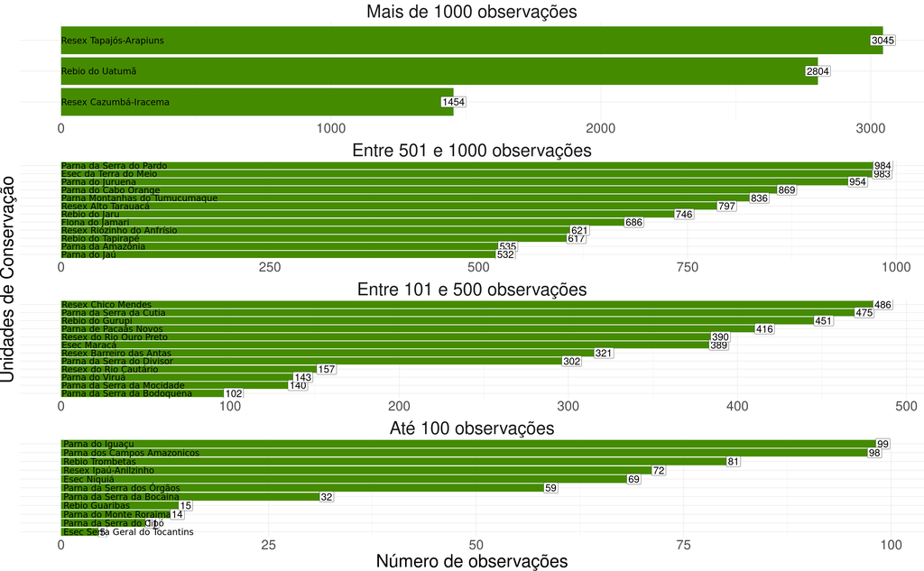

```r
# plotar o número de observações por UC
plotar_n_obs_uc_estatico()
```

#### 4.1.1.6 **Quantas observações para cada espécie?**

Número de observações por espécie.

```r
# contar total sp
n_sp <- contar_n_sp()
n_sp
```

```
[1] 209
```

```r
n_obs_sp <- contar_n_obs_sp()
n_obs_sp
```

| sp_name | sp_name_abv | n |
| --- | --- | --- |
| Aburria cujubi | Abur. cuju. | 124 |
| Aburria cumanensis | Abur. cuma. | 39 |
| Alouatta belzebul | Alou. belz. | 60 |
| Alouatta caraya | Alou. cara. | 2 |
| Alouatta discolor | Alou. disc. | 20 |
| Alouatta guariba | Alou. guar. | 2 |
| Alouatta guariba clamitans | Alou. guar. clam. | 1 |
| Alouatta juara | Alou. juar. | 14 |
| Alouatta macconnelli | Alou. macc. | 135 |
| Alouatta nigerrima | Alou. nige. | 119 |

[output cut: 199 more lines]

Esse gráfico pode melhorar. Compartilhar o eixo x? Adicionar título ao eixo x…

[figure not shown]

```r
# plotar o o número de observações por UC
plotar_n_obs_sp_estatico()
```

Tabela interativa para consulta do número de observações por espécie.

```r
# gerar tabela dinâmica com o número total de obsevações por espécie
gerar_tabdin_n_obs_sp()
```

#### 4.1.1.7 **Quais e quantas observações para cada espécie por unidades de conservação?**

```r
# gerar tabela com o número de observações por espécie e por UC
n_obs_sp_uc <- contar_n_obs_sp_uc()
n_obs_sp_uc
```

[output not shown]

**Repensar esse gráfico…** Talvez não seja necessário…

```r
plotar_n_obs_sp_uc_interativo()
```

Gerar função tabela dinâmica.

```r
gerar_tabdin_n_obs_sp_uc()
```

#### 4.1.1.8 **Quantas unidades de conservação foram amostradas em cada ano?**

Gerar função para visualizar número de UCs amostradas em cada ano. **Por agora não precisa** Se der tempo incluir ao final.

Gerar função para tabela dinâmica.

```r
gerar_tabdin_n_uc_ano()
```

#### 4.1.1.9 **Quais unidades de conservação foram amostradas em um maior número de anos?**

Gerar gráfico com o número de anos em que cada UC foi amostrada. **Por agora não precisa** Se sobrar tempo acrescentar ao final.

Tabela

```r
n_ano_uc <- contar_n_ano_uc()
n_ano_uc
```

[output not shown]

Gerar tabela dinamica.

```r
gerar_tabdin_n_ano_uc()
```

#### 4.1.1.10 **Quantas observações foram realizadas por UC em cada ano?**

```r
n_obs_uc_ano <- contar_n_obs_uc_ano()
n_obs_uc_ano
```

[output not shown]

Tabela interativa para consultar quantas observações foram realizadas por ano em cada UC

```r
gerar_tabdin_n_obs_uc_ano()
```

#### 4.1.1.11 **Quantas observações para cada espécies por ano?**

```r
n_obs_sp_ano <- contar_n_obs_sp_ano()
n_obs_sp_ano
```

[output not shown]

Tabela interativa para consultar quantas observações foram realizadas para cada espécie em cada ano

```r
gerar_tabdin_n_obs_sp_ano()
```

#### 4.1.1.12 **Quantas observações para cada espécies por UC e por ano?**

```r
n_obs_sp_uc_ano <- contar_n_obs_sp_uc_ano()
n_obs_sp_uc_ano
```

[output not shown]

Tabela interativa para consultar quantas observações foram realizadas para cada espécie em cada ano

```r
gerar_tabdin_n_obs_sp_uc_ano()
```

#### 4.1.1.13 **Quantas observações para cada espécies por UC, por estação e por ano?**

```r
n_obs_sp_uc_estacao_ano <- contar_n_obs_sp_uc_estacao_ano()
n_obs_sp_uc_estacao_ano
```

[output not shown]

```r
gerar_tabdin_n_obs_sp_uc_estacao_ano()
```

#### 4.1.1.14 **Selecionando melhores modelos de estudo considerando estratificação espacial/temporal – se há suficiência amostral (60-80 observações) por estrato**

- Possíveis estratificações espaciais – EAs/UCs

  ```
                    - UCs/Espécies
  ```

  - Possíveis estratificações temporais – Espécie/UC/Ano

#### 4.1.1.15 **Avaliando distância de truncamento**

- Gráficos de distribuição das frequências de ocorrência x distância perpendicular. Arquivos gráfico-exploratorio1.Rmd e gráfico-exploratorio2.Rmd (eu não sei como você fez para incluir aquela linha vermelha com o valor de w no gráfico exploratório 2, mas ficou legal)

#### 4.1.1.16 **Distribuição de distâncias**

```r
# gerar o gráfico exploratório da distribuição de distâncias perpendiculares para a espécies Dasyrocta croconota na Resex Tapajós-Arapiuns
fig <- dados_filtrados |>
  # excluir NA's da variável distance
  tidyr::drop_na(distance) |>
  plotar_distribuicao_distancia_interativo()

fig
```

#### 4.1.1.17 **Avaliando covariáveis**

– As covariáveis devem ser pensadas de acordo com o grupo taxonômico. Espécies que formam grupos devem ter a covariável ‘size’.

As estratégias de estratificação podem ser substituídas por covariáveis também (estratos espaciais/ ano)

Como covariável temporal, pode se pensar em usar, além do ano, a estação do ano (season), o horário do dia (para animais que variam a atividade). O horário do dia pode ser convertido em tempo após nascer do sol (como no exemplo). Mas para isso é necessário criar essa variável no dataset. E não é trivial porque precisa saber o horário de nascer do sol em cada dia/local para calcular.

**ATENÇÃO: gerar gráficos distância x covariável**

# 5 **PARTE V – Ajustando os modelos**

Esse trabalho do Marque et al. 2007 é uma boa referência de como usar as abordagens CDS global, CDS estratificada e MCDS.

Aqui, é possível testar alguns caminhos de modelos. A estratificação só faz sentido quando o volume de dados for grande. Ainda assim o uso de covariáveis pode substituir a estratificação. Pensar em como orientar o uso dessas abordagens

## 5.1 **Modelos pela abordagem CDS – dados globais**

- função ds do Distance (argumentos básicos: truncation; key, adjustment, scale… estudar argumentos para ver se mais algum interessa)

## 5.2 **Modelos pela abordagem CDS – dados estratificados**

- Aqui precisa ver direitinho os cuidados que precisa ter para ajustar as funções nos dados estratificados. Acho que faz em blocos. Vai aplicando os mesmos parâmetros para todos os estratos a cada modelo.
- para cada estrato (espacial ou temporal) usar - função ds do Distance (argumentos básicos: truncation; key, adjustment, scale… estudar argumentos para ver se mais algum interessa)

## 5.3 **Modelos pela abordagem MCDS – dados globais**

Aqui não faz sentido estratificar

- função ds do Distance (argumentos básicos: truncation; key, adjustment, scale… estudar argumentos para ver se mais algum interessa… para as covariáveis entra o argumento formula)

Dicas em Miller et al. 2019 sobre covariáveis (ver arquivo no driver).

# 6 **PARTE VI – Avaliando os modelos**

## 6.1 **Ajuste dos modelos**

- função gof_ds

– para gerar Q-Q plots e testes associados

## 6.2 **Selecionando modelos (AIC)**

– função summarize_ds_models

DICAS EXTRAS DE MILLER et al. 2019

# 7 **PARTE VII – PRODUTO FINAL**

- Como organizar
- Interatividade

**Criar expressões reativas**

reactive() eventReactive()

observe() observeEvent()

reactiveVal() reactiveValues()

isolate()

- gerar o tal documento automatizado contendo todo esse fluxo mais os resultados das análises;
- tentar transformar isso num dashboard/aplicativo único integrando cada etapa dessa numa das abas do dashboard
- Pacote targets seria últil?

# 8 **Glossário**

Descrever as variáveis (colunas), termos técnicos ao longo do texto…

- `Effort` - extensão total percorrida em metros no conjunto de dados seleciodo.